# Elixir Belgium workshop feedback

January 2018 - March 2018

Paula Andrea Martinez

2018-03-20

# Elixir Belgium workshops

## Introduction

Elixir Belgium Training has the aim to provide tools for data analysis to life scientist from all career stages. In this report we would like to share the feedback received from attendees.

## Summary of attendees

From January 2018 to March 2018 we had a total of **6** workshops at different locations around Belgium. On these workshops we received **112** attendees, from 129 applicants. The gender distribution was **44.6%** for women and **55.4%** for men.

Number of workshops by location

| Location | Number of workshops |
| --- | --- |
| Antwerp | 1 |
| Brussels | 2 |
| Ghent | 2 |
| Leuven | 1 |

# Feedback

From the above numbers we had a total of 75 responses to the voluntary and annonymous after-workshop feedback.

Please notice how much the number of feedback responses varies among different locations.

| Location | Number of responses |
| --- | --- |
| Brussels | 30 |
| Ghent | 24 |
| Leuven | 13 |
| UAntwerp | 8 |

## Visualising responses

Comparing the gender distribution of respondents, it is similar to the total gender distribution of the total attendees.

| Gender | Percentage of respondents |
| --- | --- |
| Female | 44 % |
| Male | 49.33 % |
| Prefer not to say | 6.67 % |

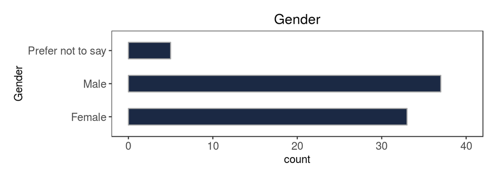

Gender distribution

Our aim is to reach all career stages, however it is clear that most attendees are PhD candidates.

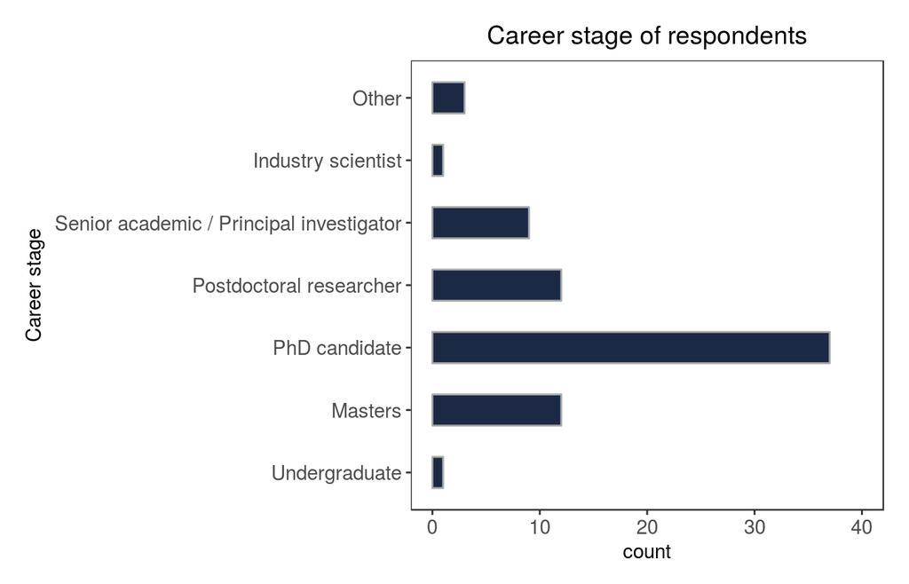

Career stages

## Workshop satisfaction

Overall the workshops are well received.

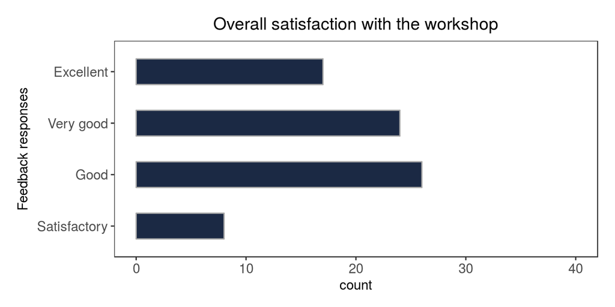

Workshop feedback

We also asked if attendees would recommend the workshop, and most people said yes.

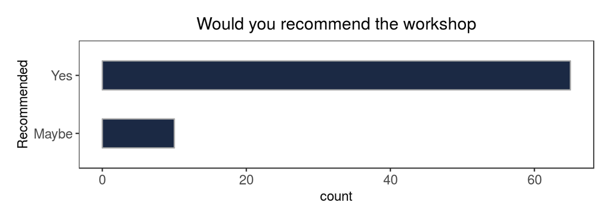

Recommendations

## Extra questions

These workshops are all bring-your-own-device. The distribution of operative systems is interesting. Most attendees use Windows computers.

OS from participants

| Operative System | Number of laptops |
| --- | --- |
| Linux | 1 |
| OS | 24 |
| Windows | 50 |

The last two questions were only included from the third workshop and have 47 responses each.

First, we asked if attendees have used the tools or resources before attending the workshop.

Have used the tools or resources before

| How often have you used the tools before | Number of responses |
| --- | --- |
| Frequently | 11 |
| Occasionally | 24 |
| Unaware of them | 9 |
| Used other service | 3 |

Then, we asked if attendees will use the tools or resources they have learned after attending the workshop.

Will use tools or resources after the workshop

| Will you use the tools or resources in the future | Number of responses |
| --- | --- |
| Maybe | 3 |
| Yes | 44 |

# Open source

This report was written in Rmarkdown and uses the open-source a default style. It has been published using Github pages. To see the Rmarkdown source of this document, you may follow this [link to github](https://github.com/orchid00/ElixirBE/blob/master/reports/2018March_nt.Rmd). This report is also available as [PDF](https://github.com/orchid00/ElixirBE/blob/master/reports/2018March_nt.pdf)

This report is freely available under [MIT License License](https://github.com/orchid00/ElixirBE/blob/master/LICENSE.md). You may re-use and adapt the material in any way you wish, without asking permission, **provided you cite the original source**. That is a [link back to this report](https://orchid00.github.io/ElixirBE/reports/2018March_nt).

I acknowledge this publication is resulting from support of [Elixir-Belgium](https://www.elixir-belgium.org/) for my role as data science and bioinformatics trainer.

Last update: 2018-03-20